# Function Parameter passing methods (*2)

## Pass by Address

```python
#include <iostream>
#include <climits>
#include <math.h>
using namespace std;
```

## Pass by Address

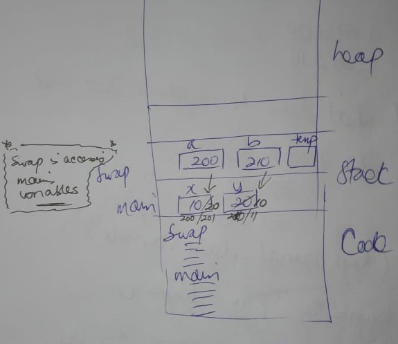

## How does it work?

*Goal: Swap values x and y*

Changes to original (pass by value):

Start of by creating (still) x and y memory space in the stack. And set the values: x = 10, y=20

```
int x = 10,
y = 20;
```

(Activation record for **main** is created, with x, y memory space is allocated. ==> Al created in STACK)

When we call **swap** now, we do not pass the value, but pass the addresses (i.e as in the stack, of x,y) as arguments:

(Activation record for **swap** is created (in STACK), but a,b now stores the addresses of x,y)

```
swap(&x, &y);
```

Will this change the signature of **swap function**? Yes

Remember only pointers can store addresses (not (normal) data variables). So we update the signature of **swap function**:

```
void swap (int *a, int *b)
```

But inside **swap** we need to do the actual work, and we need to work with values. How do we get bacl the values from the passed addresses? We need to de-reference a,b, by adding * (in front)

```
temp=*a;
a* = *b;
*b = temp;
```

Now the formal parameters CAN modify the actual parameters.

Further more...

a => address of x (e.g. 200) b => address of y (e.g. 210)

But, 200 points to 10 210 points to 20

So, temp = *a firstly a = 200, 200 = 10, i.e. a* (to get value) = 10 *a =* b firstly b = 210, 210 = 20, i.e. b *(to get value) = 20 b* = temp

### RULE: One function (**swap**), is NOT ALLOWED to access another functions (**main**) variables

### ONLY Pointers CAN DO SO :-)

So when swap changes the values of a,b, it changes the values of x, y, since the a,b **points** to x, y.. i.e. as if we working with x,y values.

This is the power of pointers: Allowing CALLED (**swap**) to change the variables of a CALLING (**main**) function

Note: Can be a mixture of addresses or normal data variables that can be passed along. e.g.:

```
swap(&x, y)
```

Also note, memory still gets created for **swap** and **main** . Although swap still needs to have memory allocation for a and b.

## Pass by Address

```python
void swap(int *a, int *b){
    int temp;
    temp=*a;
    *a=*b;
    *b=temp;
}
```

```python
int x = 10, y = 20;
cout<<x<< " " <<y<<endl;
swap(&x,&y);
cout<<x<< " " <<y<<endl;
```

```
10 20
20 10
```